# Week 01 — Blast

Author

Abby Farr

Published

November 4, 2026

## 1. This week’s analysis

Blastx  
probably not great will do blastn  
Hard to make call which Genus?

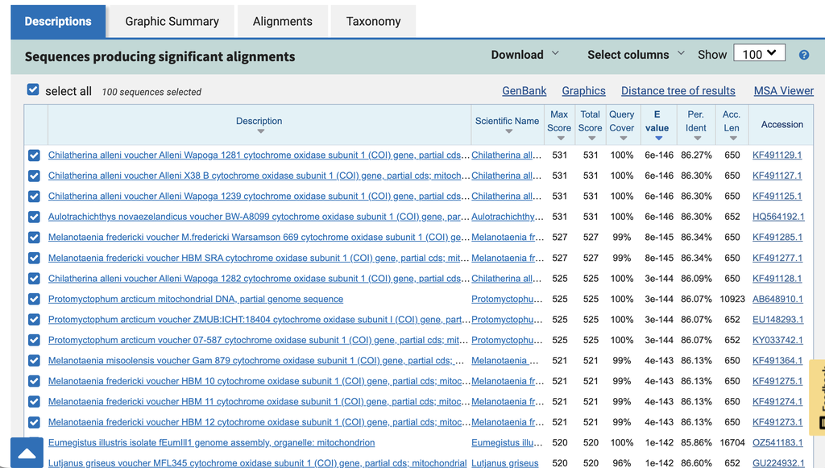

[figure not shown]

Query 182 fgN*LVPLILGAPDIAFPRINNIsf*llppsfllllAssgveagagtg*tvYPPLAGNLA 361 FGN LVPL++GAPD+AFPR+NN+SF LLPPSFLLLLASS VEAGAGTG TVYPPLAGNLA Sbjct 62 FGNWLVPLMIGAPDMAFPRMNNMSFWLLPPSFLLLLASSMVEAGAGTGWTVYPPLAGNLA 121

Query 362 HAGASVDLTIFSLHLAGVSSILGAINFITTIINMKPPAISQY 487 HAGASVDLTIFSLHLAGVSSILGAINFITTIINMKPPA+SQY Sbjct 122 HAGASVDLTIFSLHLAGVSSILGAINFITTIINMKPPALSQY 163

blastn

[figure not shown]

still tough choice 2. Reflection questions

1. sequences - closesness, how much overlap there is and (evalue) the probabilty that this match could happen by chance

> Becuase the read is so short that could explain why there are a lot of taxa listed and why there is so much overlap across taxa.
3. Nice picture (pie chart show different taxa on yellow island)

[figure not shown]

## 3. Project progress

Looking for eDNA raw data so that I can start using that in class for the project

## 4. Where I’m stuck

None

## 5. Next week

Use my data to work through steps in class and get through the tutorial before class.